# Hull Tactical Market Prediction

这是一个预测市场超额收益的竞赛。目标是预测 `market_forward_excess_returns`（市场远期超额收益）。

## 数据说明

- **date_id**: 日期标识符
- **D1-D9**: 离散特征（Discrete features）
- **E1-E20**: 经济特征（Economic features）
- **I1-I9**: 利率特征（Interest rate features）
- **M1-M18**: 动量特征（Momentum features）
- **P1-P13**: 价格特征（Price features）
- **S1-S12**: 季节性特征（Seasonal features）
- **V1-V13**: 波动率特征（Volatility features）
- **forward_returns**: 远期收益
- **risk_free_rate**: 无风险利率
- **market_forward_excess_returns**: 目标变量（市场远期超额收益）

```python
# 导入必要的库
import numpy as np
import pandas as pd
import matplotlib.pyplot as plt
import seaborn as sns
from sklearn.model_selection import TimeSeriesSplit, cross_val_score
from sklearn.preprocessing import StandardScaler
from sklearn.linear_model import Ridge, Lasso, ElasticNet
from sklearn.ensemble import RandomForestRegressor, GradientBoostingRegressor
from sklearn.metrics import mean_squared_error, mean_absolute_error, r2_score
import warnings
warnings.filterwarnings('ignore')

# 设置显示选项
pd.set_option('display.max_columns', None)
pd.set_option('display.max_rows', 100)
plt.style.use('seaborn-v0_8-darkgrid')
sns.set_palette('husl')
```

```python
## 1. 数据加载

# 加载数据
train_df = pd.read_csv('hull-tactical-market-prediction (1)/train.csv')
test_df = pd.read_csv('hull-tactical-market-prediction (1)/test.csv')

print(f"训练集形状: {train_df.shape}")
print(f"测试集形状: {test_df.shape}")

print(f"\n训练集列数: {len(train_df.columns)}")
```

```
训练集形状: (8990, 98)
测试集形状: (10, 99)

训练集列数: 98
```

```python
# 查看前几行数据
train_df.head(10)
```

|  | date_id | D1 | D2 | D3 | D4 | D5 | D6 | D7 | D8 | D9 | E1 | E10 | E11 | E12 | E13 | E14 | E15 | E16 | E17 | E18 | E19 | E2 | E20 | E3 | E4 | E5 | E6 | E7 | E8 | … |
| --- | --- | --- | --- | --- | --- | --- | --- | --- | --- | --- | --- | --- | --- | --- | --- | --- | --- | --- | --- | --- | --- | --- | --- | --- | --- | --- | --- | --- | --- | --- |
| 0 | 0 | 0 | 0 | 0 | 1 | 1 | 0 | 0 | 0 | 1 | NaN | NaN | NaN | NaN | NaN | NaN | NaN | NaN | NaN | NaN | NaN | NaN | NaN | NaN | NaN | NaN | NaN | NaN | NaN | … |
| 1 | 1 | 0 | 0 | 0 | 1 | 1 | 0 | 0 | 0 | 1 | NaN | NaN | NaN | NaN | NaN | NaN | NaN | NaN | NaN | NaN | NaN | NaN | NaN | NaN | NaN | NaN | NaN | NaN | NaN | … |
| 2 | 2 | 0 | 0 | 0 | 1 | 0 | 0 | 0 | 0 | 1 | NaN | NaN | NaN | NaN | NaN | NaN | NaN | NaN | NaN | NaN | NaN | NaN | NaN | NaN | NaN | NaN | NaN | NaN | NaN | … |
| 3 | 3 | 0 | 0 | 0 | 1 | 0 | 0 | 0 | 0 | 0 | NaN | NaN | NaN | NaN | NaN | NaN | NaN | NaN | NaN | NaN | NaN | NaN | NaN | NaN | NaN | NaN | NaN | NaN | NaN | … |
| 4 | 4 | 0 | 0 | 0 | 1 | 0 | 0 | 0 | 0 | 0 | NaN | NaN | NaN | NaN | NaN | NaN | NaN | NaN | NaN | NaN | NaN | NaN | NaN | NaN | NaN | NaN | NaN | NaN | NaN | … |
| 5 | 5 | 0 | 0 | 0 | 1 | 0 | 0 | 0 | 0 | 0 | NaN | NaN | NaN | NaN | NaN | NaN | NaN | NaN | NaN | NaN | NaN | NaN | NaN | NaN | NaN | NaN | NaN | NaN | NaN | … |
| 6 | 6 | 0 | 0 | 0 | 1 | 0 | 0 | 0 | 0 | 0 | NaN | NaN | NaN | NaN | NaN | NaN | NaN | NaN | NaN | NaN | NaN | NaN | NaN | NaN | NaN | NaN | NaN | NaN | NaN | … |
| 7 | 7 | 0 | 0 | 0 | 1 | 0 | 0 | 0 | 0 | 0 | NaN | NaN | NaN | NaN | NaN | NaN | NaN | NaN | NaN | NaN | NaN | NaN | NaN | NaN | NaN | NaN | NaN | NaN | NaN | … |
| 8 | 8 | 0 | 0 | 0 | 1 | 0 | 0 | 0 | 0 | 0 | NaN | NaN | NaN | NaN | NaN | NaN | NaN | NaN | NaN | NaN | NaN | NaN | NaN | NaN | NaN | NaN | NaN | NaN | NaN | … |
| 9 | 9 | 0 | 0 | 0 | 1 | 0 | 0 | 0 | 0 | 0 | NaN | NaN | NaN | NaN | NaN | NaN | NaN | NaN | NaN | NaN | NaN | NaN | NaN | NaN | NaN | NaN | NaN | NaN | NaN | … |

```python
# 数据基本信息
print("训练集基本信息：")
print(train_df.info())
print("\n训练集统计描述：")
train_df.describe()
```

```
训练集基本信息：
<class 'pandas.core.frame.DataFrame'>
RangeIndex: 8990 entries, 0 to 8989
Data columns (total 98 columns):
 #   Column                         Non-Null Count  Dtype
---  ------                         --------------  -----
 0   date_id                        8990 non-null   int64
 1   D1                             8990 non-null   int64
 2   D2                             8990 non-null   int64
 3   D3                             8990 non-null   int64
 4   D4                             8990 non-null   int64
 5   D5                             8990 non-null   int64
 6   D6                             8990 non-null   int64
 7   D7                             8990 non-null   int64
 8   D8                             8990 non-null   int64
```

[output cut: 94 more lines]

|  | date_id | D1 | D2 | D3 | D4 | D5 | D6 | D7 | D8 | D9 | E1 | E10 | E11 | E12 | E13 | E14 | E15 | E16 | E17 | E18 | E19 | E2 | E20 | E3 | E4 | E5 | E6 | E7 | E8 | … |
| --- | --- | --- | --- | --- | --- | --- | --- | --- | --- | --- | --- | --- | --- | --- | --- | --- | --- | --- | --- | --- | --- | --- | --- | --- | --- | --- | --- | --- | --- | --- |
| count | 8990.000000 | 8990.000000 | 8990.000000 | 8990.000000 | 8990.000000 | 8990.000000 | 8990.000000 | 8990.000000 | 8990.000000 | 8990.000000 | 7206.000000 | 7984.000000 | 7984.000000 | 7984.000000 | 7984.000000 | 7984.000000 | 7984.000000 | 7984.000000 | 7984.000000 | 7984.000000 | 7984.000000 | 7984.000000 | 7374.000000 | 7984.000000 | 7984.000000 | 7984.000000 | 7984.000000 | 2021.000000 | 7984.000000 | … |
| mean | 4494.500000 | 0.031591 | 0.031591 | 0.047831 | 0.575195 | 0.190656 | -0.238042 | 0.045717 | 0.142825 | 0.143159 | 1.564574 | 0.504941 | 0.125869 | 0.118739 | 0.012314 | 0.007005 | 0.485070 | -0.047127 | -0.007330 | 0.097865 | 0.118793 | 0.500651 | 0.902917 | 0.340552 | 0.016795 | 0.599603 | 0.122388 | -0.036545 | -0.272055 | … |
| std | 2595.333794 | 0.174917 | 0.174917 | 0.213420 | 0.494341 | 0.392840 | 0.425909 | 0.208883 | 0.349914 | 0.350254 | 0.633895 | 0.336922 | 0.245719 | 0.251961 | 0.019263 | 0.012097 | 0.348769 | 1.137741 | 1.159378 | 1.146872 | 1.247622 | 1.424679 | 1.272464 | 1.506653 | 0.041870 | 0.337506 | 0.222050 | 1.925521 | 1.514817 | … |
| min | 0.000000 | 0.000000 | 0.000000 | 0.000000 | 0.000000 | 0.000000 | -1.000000 | 0.000000 | 0.000000 | 0.000000 | 0.325149 | 0.000661 | 0.000661 | 0.000661 | 0.000661 | 0.000661 | 0.000661 | -5.130519 | -4.302885 | -4.131097 | -1.826114 | -4.675791 | -3.308764 | -5.374951 | 0.000661 | 0.000661 | 0.000661 | -19.918972 | -2.457316 | … |
| 25% | 2247.250000 | 0.000000 | 0.000000 | 0.000000 | 0.000000 | 0.000000 | 0.000000 | 0.000000 | 0.000000 | 0.000000 | 1.114633 | 0.165675 | 0.004960 | 0.003638 | 0.002976 | 0.002315 | 0.127976 | -0.766907 | -0.830320 | -0.659848 | -0.642287 | -0.560370 | 0.440873 | -0.661601 | 0.002646 | 0.305556 | 0.013228 | -0.124696 | -1.185839 | … |
| 50% | 4494.500000 | 0.000000 | 0.000000 | 0.000000 | 1.000000 | 0.000000 | 0.000000 | 0.000000 | 0.000000 | 0.000000 | 1.516651 | 0.505787 | 0.019511 | 0.006944 | 0.005291 | 0.004299 | 0.441303 | 0.001765 | 0.062710 | 0.003939 | -0.203393 | 0.693642 | 1.220291 | 0.308699 | 0.004960 | 0.650132 | 0.030754 | 0.016171 | -0.514610 | … |
| 75% | 6741.750000 | 0.000000 | 0.000000 | 0.000000 | 1.000000 | 0.000000 | 0.000000 | 0.000000 | 0.000000 | 0.000000 | 1.876977 | 0.822751 | 0.087384 | 0.074818 | 0.015212 | 0.006283 | 0.833333 | 0.763389 | 0.808831 | 0.909992 | 0.507321 | 1.638542 | 1.711411 | 1.482888 | 0.007275 | 0.953125 | 0.098545 | 0.425972 | 0.022738 | … |
| max | 8989.000000 | 1.000000 | 1.000000 | 1.000000 | 1.000000 | 1.000000 | 0.000000 | 1.000000 | 1.000000 | 1.000000 | 4.843911 | 1.000000 | 1.000000 | 1.000000 | 0.169974 | 0.118386 | 1.000000 | 2.936733 | 2.989140 | 3.024136 | 14.713768 | 3.403242 | 3.409812 | 3.619623 | 0.383267 | 1.000000 | 1.000000 | 3.509994 | 35.860072 | … |

```python
## 2. 数据探索性分析（EDA）

# 检查缺失值
missing_counts = train_df.isnull().sum()
missing_pct = (missing_counts / len(train_df)) * 100
missing_df = pd.DataFrame({
    '缺失数量': missing_counts,
    '缺失百分比': missing_pct
})
missing_df = missing_df[missing_df['缺失数量'] > 0].sort_values('缺失数量', ascending=False)
print(f"有缺失值的特征数量: {len(missing_df)}")
print("\n缺失值最多的前20个特征：")
print(missing_df.head(20))
```

```
有缺失值的特征数量: 85

缺失值最多的前20个特征：
     缺失数量      缺失百分比
E7   6969  77.519466
V10  6049  67.285873
S3   5733  63.770857
M1   5547  61.701891
M14  5540  61.624027
M13  5540  61.624027
M6   5043  56.095662
V9   4539  50.489433
S12  3537  39.343715
M5   3283  36.518354
M2   3217  35.784205
S8   3009  33.470523
M3   2018  22.447164
E1   1784  19.844271
P6   1638  18.220245
E20  1616  17.975528
P7   1616  17.975528
P5   1574  17.508343
V5   1512  16.818687
V13  1511  16.807564
```

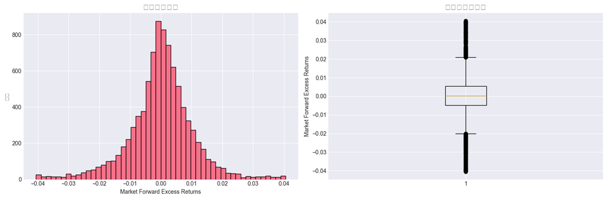

```
目标变量统计：
count    8990.000000
mean        0.000051
std         0.010568
min        -0.040582
25%        -0.004759
50%         0.000252
75%         0.005479
max         0.040551
Name: market_forward_excess_returns, dtype: float64
```

```python
# 目标变量分布
fig, axes = plt.subplots(1, 2, figsize=(15, 5))

# 直方图
axes[0].hist(train_df['market_forward_excess_returns'].dropna(), bins=50, edgecolor='black')
axes[0].set_title('目标变量分布', fontsize=14)
axes[0].set_xlabel('Market Forward Excess Returns')
axes[0].set_ylabel('频数')

# 箱线图
axes[1].boxplot(train_df['market_forward_excess_returns'].dropna())
axes[1].set_title('目标变量箱线图', fontsize=14)
axes[1].set_ylabel('Market Forward Excess Returns')

plt.tight_layout()
plt.show()

print("\n目标变量统计：")
print(train_df['market_forward_excess_returns'].describe())
```

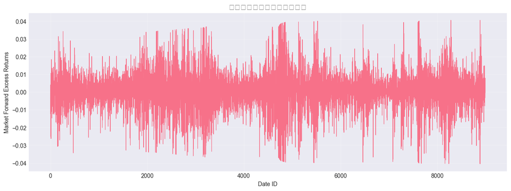

```python
# 目标变量随时间变化
plt.figure(figsize=(15, 5))
plt.plot(train_df['date_id'], train_df['market_forward_excess_returns'], linewidth=0.8)
plt.title('市场远期超额收益随时间变化', fontsize=14)
plt.xlabel('Date ID')
plt.ylabel('Market Forward Excess Returns')
plt.grid(True, alpha=0.3)
plt.show()
```

```python
# 分析不同类型的特征
feature_groups = {
    'Discrete': [col for col in train_df.columns if col.startswith('D')],
    'Economic': [col for col in train_df.columns if col.startswith('E')],
    'Interest Rate': [col for col in train_df.columns if col.startswith('I')],
    'Momentum': [col for col in train_df.columns if col.startswith('M')],
    'Price': [col for col in train_df.columns if col.startswith('P')],
    'Seasonal': [col for col in train_df.columns if col.startswith('S')],
    'Volatility': [col for col in train_df.columns if col.startswith('V')]
}

print("特征组统计：")
for group_name, cols in feature_groups.items():
    print(f"{group_name}: {len(cols)} 个特征")
```

```
特征组统计：
Discrete: 9 个特征
Economic: 20 个特征
Interest Rate: 9 个特征
Momentum: 18 个特征
Price: 13 个特征
Seasonal: 12 个特征
Volatility: 13 个特征
```

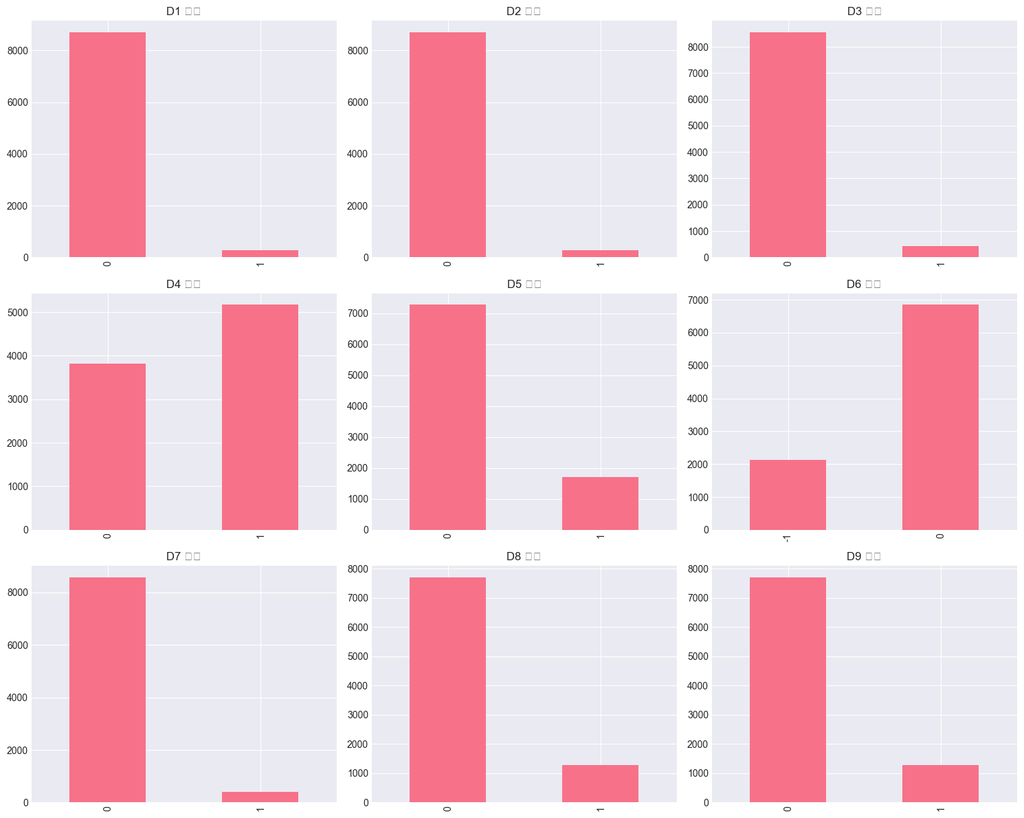

```python
# 离散特征的分布
discrete_cols = feature_groups['Discrete']
fig, axes = plt.subplots(3, 3, figsize=(15, 12))
axes = axes.ravel()

for idx, col in enumerate(discrete_cols):
    train_df[col].value_counts().sort_index().plot(kind='bar', ax=axes[idx])
    axes[idx].set_title(f'{col} 分布')
    axes[idx].set_xlabel('')

plt.tight_layout()
plt.show()
```

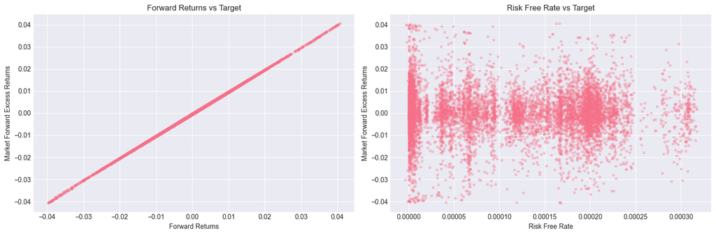

```
相关系数：
forward_returns 与目标相关性: 1.0000
risk_free_rate 与目标相关性: -0.0095
```

```python
# 检查 forward_returns 和 risk_free_rate 与目标的关系
fig, axes = plt.subplots(1, 2, figsize=(15, 5))

# forward_returns vs target
axes[0].scatter(train_df['forward_returns'],
                train_df['market_forward_excess_returns'],
                alpha=0.3, s=10)
axes[0].set_xlabel('Forward Returns')
axes[0].set_ylabel('Market Forward Excess Returns')
axes[0].set_title('Forward Returns vs Target')

# risk_free_rate vs target
axes[1].scatter(train_df['risk_free_rate'],
                train_df['market_forward_excess_returns'],
                alpha=0.3, s=10)
axes[1].set_xlabel('Risk Free Rate')
axes[1].set_ylabel('Market Forward Excess Returns')
axes[1].set_title('Risk Free Rate vs Target')

plt.tight_layout()
plt.show()

print("\n相关系数：")
print(f"forward_returns 与目标相关性: {train_df['forward_returns'].corr(train_df['market_forward_excess_returns']):.4f}")
print(f"risk_free_rate 与目标相关性: {train_df['risk_free_rate'].corr(train_df['market_forward_excess_returns']):.4f}")
```

```python
## 3. 特征工程

# 准备特征和目标
def prepare_features(df, is_train=True):
    df = df.copy()

    # 排除的列
    exclude_cols = ['date_id']
    if is_train:
        exclude_cols.extend(['market_forward_excess_returns'])

    # 获取所有特征列
    feature_cols = [col for col in df.columns if col not in exclude_cols]

    # 填充缺失值（使用中位数）
    for col in feature_cols:
        if df[col].isnull().any():
            df[col].fillna(df[col].median(), inplace=True)

    return df, feature_cols

# 准备训练数据
train_processed, feature_cols = prepare_features(train_df, is_train=True)
X = train_processed[feature_cols]
y = train_df['market_forward_excess_returns']

print(f"特征数量: {len(feature_cols)}")
print(f"训练样本数量: {len(X)}")
print(f"\n特征列表（前20个）: {feature_cols[:20]}")
```

```
特征数量: 96
训练样本数量: 8990

特征列表（前20个）: ['D1', 'D2', 'D3', 'D4', 'D5', 'D6', 'D7', 'D8', 'D9', 'E1', 'E10', 'E11', 'E12', 'E13', 'E14', 'E15', 'E16', 'E17', 'E18', 'E19']
```

```python
# 创建额外的特征
def create_advanced_features(df, feature_cols):
    df = df.copy()
    new_features = []

    # 如果 forward_returns 和 risk_free_rate 存在，创建交互特征
    if 'forward_returns' in feature_cols and 'risk_free_rate' in feature_cols:
        df['returns_rate_interaction'] = df['forward_returns'] * df['risk_free_rate']
        df['returns_rate_diff'] = df['forward_returns'] - df['risk_free_rate']
        new_features.extend(['returns_rate_interaction', 'returns_rate_diff'])

    # 为每组特征创建统计量
    for prefix in ['E', 'I', 'M', 'P', 'S', 'V']:
        group_cols = [col for col in feature_cols if col.startswith(prefix)]
        if len(group_cols) > 0:
            # 只选择有值的列
            group_data = df[group_cols]
            df[f'{prefix}_mean'] = group_data.mean(axis=1)
            df[f'{prefix}_std'] = group_data.std(axis=1)
            df[f'{prefix}_max'] = group_data.max(axis=1)
            df[f'{prefix}_min'] = group_data.min(axis=1)
            new_features.extend([f'{prefix}_mean', f'{prefix}_std', f'{prefix}_max', f'{prefix}_min'])

    return df, new_features

# 应用高级特征工程
X_enhanced, new_features = create_advanced_features(X, feature_cols)
all_features = feature_cols + new_features
X_enhanced = X_enhanced[all_features]

print(f"增强后的特征数量: {len(all_features)}")
print(f"新增特征: {new_features}")
```

```
增强后的特征数量: 122
新增特征: ['returns_rate_interaction', 'returns_rate_diff', 'E_mean', 'E_std', 'E_max', 'E_min', 'I_mean', 'I_std', 'I_max', 'I_min', 'M_mean', 'M_std', 'M_max', 'M_min', 'P_mean', 'P_std', 'P_max', 'P_min', 'S_mean', 'S_std', 'S_max', 'S_min', 'V_mean', 'V_std', 'V_max', 'V_min']
```

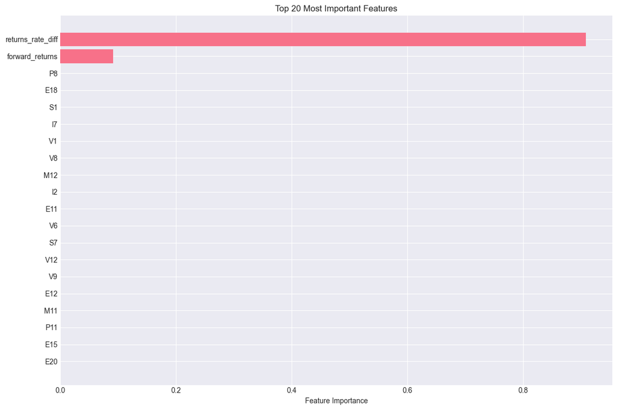

```
Top 20 重要特征：
              feature  importance
97  returns_rate_diff    0.908866
94    forward_returns    0.091016
67                 P8    0.000010
18                E18    0.000005
69                 S1    0.000005
35                 I7    0.000005
81                 V1    0.000004
92                 V8    0.000004
41                M12    0.000004
30                 I2    0.000003
11                E11    0.000003
90                 V6    0.000003
78                 S7    0.000003
84                V12    0.000003
93                 V9    0.000003
12                E12    0.000003
40                M11    0.000002
58                P11    0.000002
15                E15    0.000002
21                E20    0.000002
```

```python
# 特征重要性分析（使用随机森林）
from sklearn.ensemble import RandomForestRegressor

# 使用小样本快速训练
sample_size = min(5000, len(X_enhanced))
X_sample = X_enhanced.iloc[:sample_size]
y_sample = y.iloc[:sample_size]

rf_temp = RandomForestRegressor(n_estimators=50, max_depth=10, random_state=42, n_jobs=-1)
rf_temp.fit(X_sample, y_sample)

# 特征重要性
feature_importance = pd.DataFrame({
    'feature': all_features,
    'importance': rf_temp.feature_importances_
}).sort_values('importance', ascending=False)

# 绘制top 20特征
plt.figure(figsize=(12, 8))
top_features = feature_importance.head(20)
plt.barh(range(len(top_features)), top_features['importance'])
plt.yticks(range(len(top_features)), top_features['feature'])
plt.xlabel('Feature Importance')
plt.title('Top 20 Most Important Features')
plt.gca().invert_yaxis()
plt.tight_layout()
plt.show()

print("\nTop 20 重要特征：")
print(feature_importance.head(20))
```

## 4. 模型训练与评估

使用时间序列交叉验证来评估模型，因为这是时间序列数据。

```python
# 标准化特征
scaler = StandardScaler()
X_scaled = scaler.fit_transform(X_enhanced)
X_scaled = pd.DataFrame(X_scaled, columns=all_features, index=X_enhanced.index)

# 时间序列交叉验证
tscv = TimeSeriesSplit(n_splits=5)

print("时间序列交叉验证设置完成")
print(f"折数: 5")
```

```
时间序列交叉验证设置完成
折数: 5
```

```python
# 定义评估函数
def evaluate_model(model, X, y, cv):
    """
    使用交叉验证评估模型
    """
    scores = {
        'mse': [],
        'rmse': [],
        'mae': [],
        'r2': []
    }

    for fold, (train_idx, val_idx) in enumerate(cv.split(X), 1):
        X_train_fold, X_val_fold = X.iloc[train_idx], X.iloc[val_idx]
        y_train_fold, y_val_fold = y.iloc[train_idx], y.iloc[val_idx]

        model.fit(X_train_fold, y_train_fold)
        y_pred = model.predict(X_val_fold)

        mse = mean_squared_error(y_val_fold, y_pred)
        scores['mse'].append(mse)
        scores['rmse'].append(np.sqrt(mse))
        scores['mae'].append(mean_absolute_error(y_val_fold, y_pred))
        scores['r2'].append(r2_score(y_val_fold, y_pred))

        print(f"Fold {fold}: RMSE = {np.sqrt(mse):.6f}, R2 = {scores['r2'][-1]:.4f}")

    print(f"\n平均 RMSE: {np.mean(scores['rmse']):.6f} (+/- {np.std(scores['rmse']):.6f})")
    print(f"平均 MAE: {np.mean(scores['mae']):.6f} (+/- {np.std(scores['mae']):.6f})")
    print(f"平均 R2: {np.mean(scores['r2']):.4f} (+/- {np.std(scores['r2']):.4f})")

    return scores
```

```python
# 训练线性回归模型（Ridge）
print("="*60)
print("训练 Ridge 回归模型")
print("="*60)
ridge_model = Ridge(alpha=1.0, random_state=42)
ridge_scores = evaluate_model(ridge_model, X_scaled, y, tscv)
```

```
============================================================
训练 Ridge 回归模型
============================================================
Fold 1: RMSE = 0.000056, R2 = 1.0000
Fold 2: RMSE = 0.000070, R2 = 0.9999
Fold 3: RMSE = 0.000090, R2 = 1.0000
Fold 4: RMSE = 0.000044, R2 = 1.0000
Fold 5: RMSE = 0.000054, R2 = 1.0000

平均 RMSE: 0.000063 (+/- 0.000016)
平均 MAE: 0.000034 (+/- 0.000011)
平均 R2: 1.0000 (+/- 0.0000)
```

```python
# 训练Lasso模型
print("\n" + "="*60)
print("训练 Lasso 回归模型")
print("="*60)
lasso_model = Lasso(alpha=0.001, random_state=42, max_iter=5000)
lasso_scores = evaluate_model(lasso_model, X_scaled, y, tscv)
```

```
============================================================
训练 Lasso 回归模型
============================================================
Fold 1: RMSE = 0.003734, R2 = 0.9046
Fold 2: RMSE = 0.005218, R2 = 0.7169
Fold 3: RMSE = 0.002736, R2 = 0.9577
Fold 4: RMSE = 0.000732, R2 = 0.9920
Fold 5: RMSE = 0.001120, R2 = 0.9903

平均 RMSE: 0.002708 (+/- 0.001660)
平均 MAE: 0.001840 (+/- 0.001069)
平均 R2: 0.9123 (+/- 0.1027)
```

```python
# 训练弹性网络模型
print("\n" + "="*60)
print("训练 ElasticNet 回归模型")
print("="*60)
elastic_model = ElasticNet(alpha=0.001, l1_ratio=0.5, random_state=42, max_iter=5000)
elastic_scores = evaluate_model(elastic_model, X_scaled, y, tscv)
```

```
============================================================
训练 ElasticNet 回归模型
============================================================
Fold 1: RMSE = 0.001930, R2 = 0.9745
Fold 2: RMSE = 0.002619, R2 = 0.9287
Fold 3: RMSE = 0.001403, R2 = 0.9889
Fold 4: RMSE = 0.000365, R2 = 0.9980
Fold 5: RMSE = 0.000566, R2 = 0.9975

平均 RMSE: 0.001377 (+/- 0.000841)
平均 MAE: 0.000932 (+/- 0.000542)
平均 R2: 0.9775 (+/- 0.0259)
```

```python
# 训练随机森林模型
print("\n" + "="*60)
print("训练 Random Forest 模型")
print("="*60)
rf_model = RandomForestRegressor(
    n_estimators=100,
    max_depth=15,
    min_samples_split=10,
    min_samples_leaf=5,
    random_state=42,
    n_jobs=-1
)
rf_scores = evaluate_model(rf_model, X_enhanced, y, tscv)
```

```
============================================================
训练 Random Forest 模型
============================================================
Fold 1: RMSE = 0.001158, R2 = 0.9908
Fold 2: RMSE = 0.000152, R2 = 0.9998
Fold 3: RMSE = 0.000527, R2 = 0.9984
Fold 4: RMSE = 0.000034, R2 = 1.0000
Fold 5: RMSE = 0.000121, R2 = 0.9999

平均 RMSE: 0.000398 (+/- 0.000416)
平均 MAE: 0.000095 (+/- 0.000101)
平均 R2: 0.9978 (+/- 0.0035)
```

```python
# 训练梯度提升模型
print("\n" + "="*60)
print("训练 Gradient Boosting 模型")
print("="*60)
gb_model = GradientBoostingRegressor(
    n_estimators=100,
    max_depth=5,
    learning_rate=0.1,
    subsample=0.8,
    random_state=42
)
gb_scores = evaluate_model(gb_model, X_enhanced, y, tscv)
```

```
============================================================
训练 Gradient Boosting 模型
============================================================
Fold 1: RMSE = 0.000246, R2 = 0.9996
Fold 2: RMSE = 0.000099, R2 = 0.9999
Fold 3: RMSE = 0.000411, R2 = 0.9990
Fold 4: RMSE = 0.000043, R2 = 1.0000
Fold 5: RMSE = 0.000083, R2 = 0.9999

平均 RMSE: 0.000176 (+/- 0.000136)
平均 MAE: 0.000059 (+/- 0.000031)
平均 R2: 0.9997 (+/- 0.0004)
```

```
============================================================
模型性能对比
============================================================
            Model  Mean RMSE  Std RMSE  Mean R2
            Ridge   0.000063  0.000016 0.999966
Gradient Boosting   0.000176  0.000136 0.999690
    Random Forest   0.000398  0.000416 0.997778
       ElasticNet   0.001377  0.000841 0.977526
            Lasso   0.002708  0.001660 0.912316
```

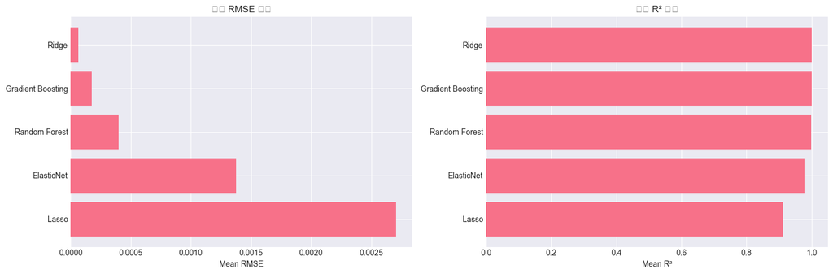

```python
# 模型对比
model_comparison = pd.DataFrame({
    'Model': ['Ridge', 'Lasso', 'ElasticNet', 'Random Forest', 'Gradient Boosting'],
    'Mean RMSE': [
        np.mean(ridge_scores['rmse']),
        np.mean(lasso_scores['rmse']),
        np.mean(elastic_scores['rmse']),
        np.mean(rf_scores['rmse']),
        np.mean(gb_scores['rmse'])
    ],
    'Std RMSE': [
        np.std(ridge_scores['rmse']),
        np.std(lasso_scores['rmse']),
        np.std(elastic_scores['rmse']),
        np.std(rf_scores['rmse']),
        np.std(gb_scores['rmse'])
    ],
    'Mean R2': [
        np.mean(ridge_scores['r2']),
        np.mean(lasso_scores['r2']),
        np.mean(elastic_scores['r2']),
        np.mean(rf_scores['r2']),
        np.mean(gb_scores['r2'])
    ]
}).sort_values('Mean RMSE')

print("\n" + "="*60)
print("模型性能对比")
print("="*60)
print(model_comparison.to_string(index=False))

# 可视化对比
fig, axes = plt.subplots(1, 2, figsize=(15, 5))

# RMSE对比
axes[0].barh(model_comparison['Model'], model_comparison['Mean RMSE'])
axes[0].set_xlabel('Mean RMSE')
axes[0].set_title('模型 RMSE 对比')
axes[0].invert_yaxis()

# R2对比
axes[1].barh(model_comparison['Model'], model_comparison['Mean R2'])
axes[1].set_xlabel('Mean R²')
axes[1].set_title('模型 R² 对比')
axes[1].invert_yaxis()

plt.tight_layout()
plt.show()
```

```python
## 5. 使用最佳模型进行预测

# 选择最佳模型并在全部训练数据上训练
# 这里我们选择表现最好的模型
best_model_name = model_comparison.iloc[0]['Model']
print(f"最佳模型: {best_model_name}")

# 根据最佳模型名称选择模型
if best_model_name == 'Ridge':
    final_model = Ridge(alpha=1.0, random_state=42)
    X_final = X_scaled
elif best_model_name == 'Lasso':
    final_model = Lasso(alpha=0.001, random_state=42, max_iter=5000)
    X_final = X_scaled
elif best_model_name == 'ElasticNet':
    final_model = ElasticNet(alpha=0.001, l1_ratio=0.5, random_state=42, max_iter=5000)
    X_final = X_scaled
elif best_model_name == 'Random Forest':
    final_model = RandomForestRegressor(
        n_estimators=100, max_depth=15, min_samples_split=10,
        min_samples_leaf=5, random_state=42, n_jobs=-1
    )
    X_final = X_enhanced
else:  # Gradient Boosting
    final_model = GradientBoostingRegressor(
        n_estimators=100, max_depth=5, learning_rate=0.1,
        subsample=0.8, random_state=42
    )
    X_final = X_enhanced

# 在全部训练数据上训练
print("\n在全部训练数据上训练最终模型...")
final_model.fit(X_final, y)
print("训练完成！")
```

```
最佳模型: Ridge

在全部训练数据上训练最终模型...
训练完成！
```

```python
# 如果测试集有数据，进行预测
if len(test_df) > 0:
    print("准备测试集数据...")
    test_processed, _ = prepare_features(test_df, is_train=False)
    X_test = test_processed[feature_cols]
    X_test_enhanced, _ = create_advanced_features(X_test, feature_cols)
    X_test_enhanced = X_test_enhanced[all_features]

    # 根据模型类型选择是否标准化
    if best_model_name in ['Ridge', 'Lasso', 'ElasticNet']:
        X_test_final = scaler.transform(X_test_enhanced)
        X_test_final = pd.DataFrame(X_test_final, columns=all_features)
    else:
        X_test_final = X_test_enhanced

    # 进行预测
    print("进行预测...")
    predictions = final_model.predict(X_test_final)

    # 创建提交文件
    submission = pd.DataFrame({
        'date_id': test_df['date_id'],
        'market_forward_excess_returns': predictions
    })

    submission.to_csv('submission.csv', index=False)
    print("\n提交文件已保存: submission.csv")
    print(f"预测样本数: {len(submission)}")
    print("\n预测结果统计:")
    print(submission['market_forward_excess_returns'].describe())
else:
    print("测试集为空或没有数据需要预测")
```

```
准备测试集数据...
```

[output not shown]

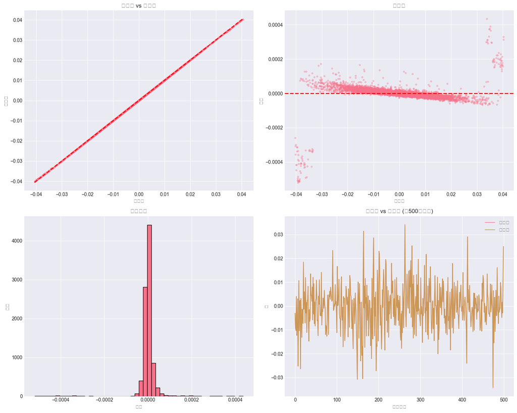

```
训练集最终性能:
RMSE: 0.000041
MAE: 0.000015
R²: 1.0000
```

```python
# 可视化预测结果（使用训练集的预测）
train_predictions = final_model.predict(X_final)

fig, axes = plt.subplots(2, 2, figsize=(15, 12))

# 实际值 vs 预测值
axes[0, 0].scatter(y, train_predictions, alpha=0.3, s=10)
axes[0, 0].plot([y.min(), y.max()], [y.min(), y.max()], 'r--', lw=2)
axes[0, 0].set_xlabel('实际值')
axes[0, 0].set_ylabel('预测值')
axes[0, 0].set_title('实际值 vs 预测值')

# 残差图
residuals = y - train_predictions
axes[0, 1].scatter(train_predictions, residuals, alpha=0.3, s=10)
axes[0, 1].axhline(y=0, color='r', linestyle='--', lw=2)
axes[0, 1].set_xlabel('预测值')
axes[0, 1].set_ylabel('残差')
axes[0, 1].set_title('残差图')

# 残差分布
axes[1, 0].hist(residuals, bins=50, edgecolor='black')
axes[1, 0].set_xlabel('残差')
axes[1, 0].set_ylabel('频数')
axes[1, 0].set_title('残差分布')

# 时间序列对比
sample_size = min(500, len(y))
axes[1, 1].plot(range(sample_size), y.iloc[:sample_size], label='实际值', alpha=0.7)
axes[1, 1].plot(range(sample_size), train_predictions[:sample_size], label='预测值', alpha=0.7)
axes[1, 1].set_xlabel('样本索引')
axes[1, 1].set_ylabel('值')
axes[1, 1].set_title('实际值 vs 预测值 (前500个样本)')
axes[1, 1].legend()

plt.tight_layout()
plt.show()

# 计算训练集指标
train_rmse = np.sqrt(mean_squared_error(y, train_predictions))
train_mae = mean_absolute_error(y, train_predictions)
train_r2 = r2_score(y, train_predictions)

print(f"\n训练集最终性能:")
print(f"RMSE: {train_rmse:.6f}")
print(f"MAE: {train_mae:.6f}")
print(f"R²: {train_r2:.4f}")
```

## 6. 总结

### 改进方向：

- 尝试更复杂的特征工程（滞后特征、移动平均等）
- 超参数调优（使用GridSearchCV或RandomizedSearchCV）
- 集成学习方法（Stacking, Blending）
- 尝试深度学习模型（LSTM, Transformer等用于时间序列）
- 处理异常值和离群点